# Análisis Espacial y Agrupamiento de la Sismicidad de Alto Impacto en México (Magnitud>=5)

## 5.5 Evaluación de Clústeres

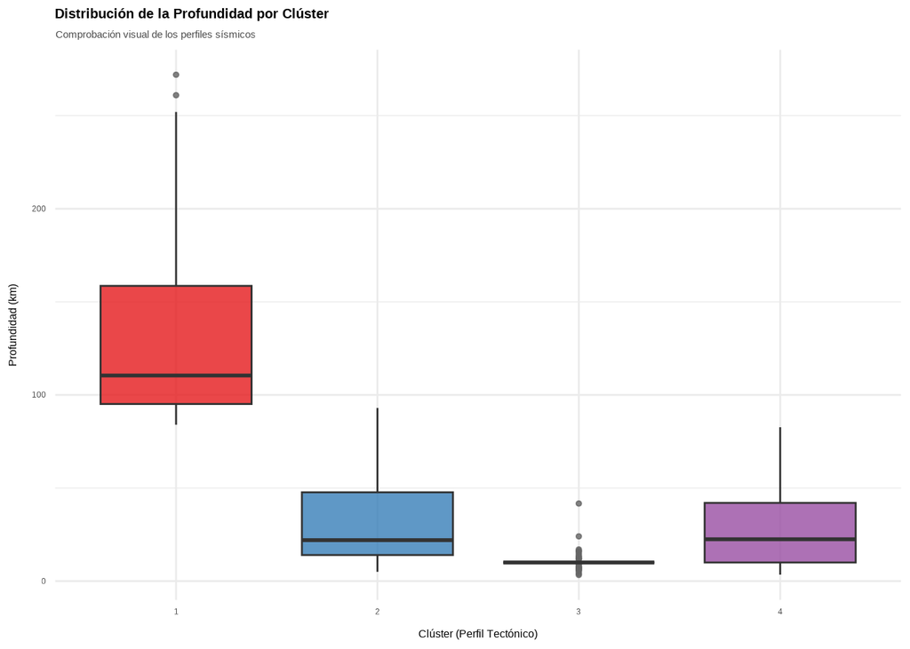

```r
ggplot(df, aes(x = cluster, y = depth, fill = cluster)) +
  geom_boxplot(alpha = 0.8, outlier.color = "gray40", outlier.size = 1) +
  scale_fill_brewer(palette = "Set1") +
  labs(
    title = "Distribución de la Profundidad por Clúster",
    subtitle = "Comprobación visual de los perfiles sísmicos",
    x = "Clúster (Perfil Tectónico)",
    y = "Profundidad (km)"
  ) +
  tema +
  theme(legend.position = "none")
```

```r
# Asegurar que la variable cluster sea un factor (categórica)
df$cluster <- as.factor(df$cluster)

# ==========================================
# ANÁLISIS DE LA PROFUNDIDAD
# ==========================================

# Prueba global de Kruskal-Wallis
kw_profundidad <- kruskal.test(depth ~ cluster, data = df)
p_value_kw_prof <- kw_profundidad$p.value
print("--- Kruskal-Wallis: Profundidad ---")
```

```
## [1] "--- Kruskal-Wallis: Profundidad ---"
```

```r
print(kw_profundidad)
```

```
##
##  Kruskal-Wallis rank sum test
##
## data:  depth by cluster
## Kruskal-Wallis chi-squared = 210.8, df = 3, p-value < 2.2e-16
```

```r
# Prueba Post-hoc (¿Qué clústeres son distintos entre sí?)
posthoc_profundidad <- pairwise.wilcox.test(
  df$depth,
  df$cluster,
  p.adjust.method = "bonferroni"
)
print("--- Diferencias por pares (Profundidad) ---")
```

```
## [1] "--- Diferencias por pares (Profundidad) ---"
```

```r
print(posthoc_profundidad$p.value)
```

```
##              1            2  3
## 2 1.260149e-10           NA NA
## 3 4.244579e-27 3.726159e-09 NA
## 4 3.738925e-28 1.000000e+00  0
```

**Interpretación de Profundidad por Clúster:** La prueba global de Kruskal-Wallis (1.9535547^{-45}) confirma de manera contundente que la profundidad no se distribuye al azar entre los grupos; el algoritmo K-Means logró identificar perfiles geofísicos reales y diferenciados. El Clúster 1 aísla la sismicidad profunda (estadísticamente distinto a los demás, p≈0). El Clúster 3 define un régimen ultra-superficial y rígido comprimido a ~10km. Los Clústeres 2 y 4 son idénticos en profundidad (p=1.0000), ambos representan fricción costera superficial, demostrando que el algoritmo los separó por latitud/longitud o magnitud.

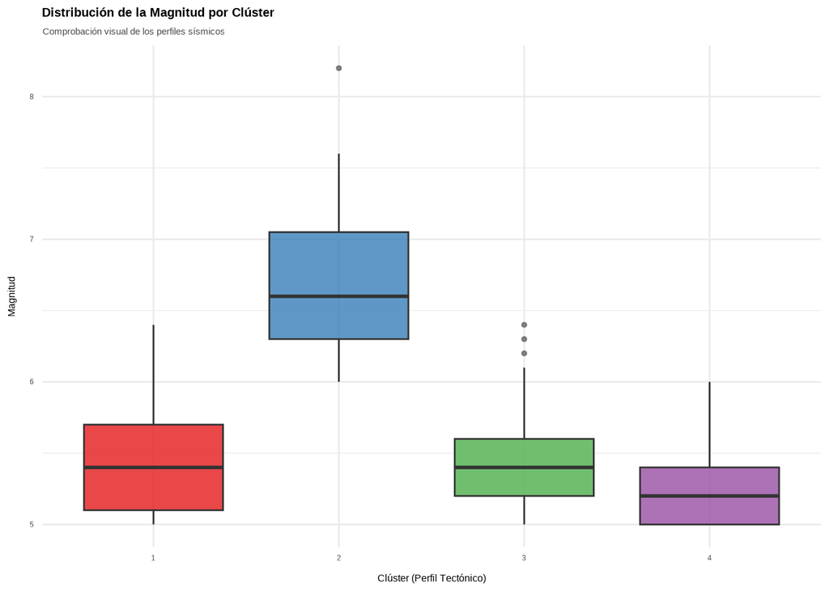

```r
ggplot(df, aes(x = cluster, y = mag, fill = cluster)) +
  geom_boxplot(alpha = 0.8, outlier.color = "gray40", outlier.size = 1) +
  scale_fill_brewer(palette = "Set1") +
  labs(
    title = "Distribución de la Magnitud por Clúster",
    subtitle = "Comprobación visual de los perfiles sísmicos",
    x = "Clúster (Perfil Tectónico)",
    y = "Magnitud"
  ) +
  tema +
  theme(legend.position = "none")
```

```r
# ==========================================
# ANÁLISIS DE LA MAGNITUD
# ==========================================

# 4. Prueba global de Kruskal-Wallis
kw_magnitud <- kruskal.test(mag ~ cluster, data = df)
p_value_kw_mag <- kw_magnitud$p.value
print("--- Kruskal-Wallis: Magnitud ---")
```

```
## [1] "--- Kruskal-Wallis: Magnitud ---"
```

```r
print(kw_magnitud)
```

```
##
##  Kruskal-Wallis rank sum test
##
## data:  mag by cluster
## Kruskal-Wallis chi-squared = 90.806, df = 3, p-value < 2.2e-16
```

```r
# 5. Prueba Post-hoc
posthoc_magnitud <- pairwise.wilcox.test(
  df$mag,
  df$cluster,
  p.adjust.method = "bonferroni"
)
print("--- Diferencias por pares (Magnitud) ---")
```

```
## [1] "--- Diferencias por pares (Magnitud) ---"
```

```r
print(posthoc_magnitud$p.value)
```

```
##              1            2          3
## 2 1.344058e-10           NA         NA
## 3 1.000000e+00 6.989434e-13         NA
## 4 6.980373e-02 6.794610e-15 1.0089e-06
```

**Interpretación de Magnitud por Clúster:** El Clúster 2 concentra los eventos extremos y macrosismos, estadísticamente diferente a todos los demás (p≈0). El Clúster 4 es el grupo con la mediana de magnitud más baja (alrededor de 5.2). Los Clústeres 1 y 3 tienen magnitudes medias estadísticamente idénticas (p=1.0000) aunque ocurran en zonas tectónicas muy distintas. Esto demuestra que K-Means usó la magnitud para aislar los sismos extremos en el Clúster 2.

# 6 Conclusiones y Resumen Consolidado

```r
resumen_consolidado <- tibble(
  metrica = c("Total de eventos", "Periodo cubierto", "Magnitud promedio", "Magnitud mediana", "Profundidad promedio (km)"),
  valor = c(nrow(df), paste(min(df$anio_evento, na.rm = TRUE), "-", max(df$anio_evento, na.rm = TRUE)), round(mean(df$mag, na.rm = TRUE), 2), round(median(df$mag, na.rm = TRUE), 2), round(mean(df$depth, na.rm = TRUE), 2))
)
kable(resumen_consolidado)
```

| metrica | valor |
| --- | --- |
| Total de eventos | 423 |
| Periodo cubierto | 2015 - 2026 |
| Magnitud promedio | 5.4 |
| Magnitud mediana | 5.3 |
| Profundidad promedio (km) | 36.69 |

```r
resumen_final <- tibble(
  Hallazgo = c(
    "Correlación prof ↔ mag (Pearson)",
    "Correlación prof ↔ mag (Spearman)",
    "b-value (Gutenberg-Richter)",
    "R² ajuste G-R",
    "Región más activa",
    "Región con mayor M media",
    "% eventos superficiales",
    "Réplicas del evento principal",
    "Estadístico de Hopkins (tendencia de clustering)",
    "Outliers multivariados (Mahalanobis, chi2 97.5%)"
  ),
  Valor = c(
    round(cor(df_num$depth, df_num$mag), 3),
    round(cor(df_num$depth, df_num$mag, method = "spearman"), 3),
    round(b_value, 3),
    round(summary(gr_fit)$r.squared, 3),
    perfil_region$region_tectonica[which.max(perfil_region$n_eventos)],
    perfil_region$region_tectonica[which.max(perfil_region$mag_media)],
    paste0(round(100 * mean(df$depth < 70, na.rm = TRUE), 1), "%"),
    as.character(nrow(replicas)),
    round(hopkins_res$hopkins_stat, 3),
    paste0(n_outliers_multi, " (", round(100 * n_outliers_multi / nrow(df_num), 1), "%)")
  )
)
kable(resumen_final, caption = "Resumen ejecutivo del análisis descriptivo")
```

Resumen ejecutivo del análisis descriptivo

| Hallazgo | Valor |
| --- | --- |
| Correlación prof ↔︎ mag (Pearson) | 0.012 |
| Correlación prof ↔︎ mag (Spearman) | -0.087 |
| b-value (Gutenberg-Richter) | 0.856 |
| R² ajuste G-R | 0.988 |
| Región más activa | 3 |
| Región con mayor M media | 1 |
| % eventos superficiales | 85.6% |
| Réplicas del evento principal | 47 |
| Estadístico de Hopkins (tendencia de clustering) | 1 |
| Outliers multivariados (Mahalanobis, chi2 97.5%) | 30 (7.1%) |

**Interpretación de Cierre:** Esta tabla reúne la evidencia que responde a las preguntas secundarias del proyecto (correlación profundidad-magnitud, regiones diferenciadas, patrones temporales, y la ley frecuencia-magnitud), y los diagnósticos que justificaron metodológicamente el modelado espacial. El estadístico de Hopkins comprobó la estructura de agrupamiento real, y el análisis K-Means logró segmentar con éxito el catálogo en regímenes tectónicos estadísticamente fundamentados.

# 7 Limitaciones, Posibles Extensiones y Conclusión General

Entre las principales limitaciones del proyecto destacan que el análisis se restringe a sismos $M \ge 5$ (sin generalizarse a la microsismicidad), que el bounding box es una conveniencia geográfica y no una frontera tectónica real, que no puede descartarse un sesgo instrumental en la tendencia temporal observada y que la secuencia de réplicas se basa en un único evento principal (n=1); como posibles extensiones se sugiere evaluar algoritmos de agrupamiento jerárquico, afinar la parametrización espacial de DBSCAN para distintas regiones tectónicas, repetir el análisis de réplicas sobre varios eventos M≥7 en vez de uno solo, ajustar un modelo de series de tiempo para pronosticar frecuencia futura, incorporar variables de calidad de detección del catálogo (gap, nst, rms) y cruzar los perfiles sísmicos con datos de densidad poblacional para pasar de actividad a riesgo; y en conclusión general, la evidencia acumulada —el Estadístico de Hopkins (1) confirmando estructura real de agrupamiento, el Índice de Moran mostrando autocorrelación fuerte en profundidad (0.707) pero casi nula en magnitud (0.079), los cuatro perfiles de K-Means validados estadísticamente con Kruskal-Wallis y post-hoc, la exitosa implementación de DBSCAN que superó la limitación de asumir clústeres esféricos al adaptarse a la geometría lineal de las fallas, la independencia entre profundidad y magnitud (Pearson ≈ 0.01), y el ajuste de Gutenberg-Richter (b = 0.86, R² = 0.988)— confirma que la sismicidad de alto impacto en México sí se distribuye de forma heterogénea y agrupable en perfiles distinguibles matemáticamente, aunque el alcance de esta conclusión queda acotado por las limitaciones señaladas.

# 8 Bibliografía

Bird, P. (2003). An updated digital model of plate boundaries. *Geochemistry, Geophysics, Geosystems*, 4(3). Obtenido del repositorio GitHub: https://github.com/fraxen/tectonicplates/tree/master

R Core Team. (2026). *R: A language and environment for statistical computing*. R Foundation for Statistical Computing, Vienna, Austria.

Servicio Sismológico Nacional (SSN). (2021). *Catálogo de sismos*. Instituto de Geofísica, Universidad Nacional Autónoma de México, México. URL: http://www.ssn.unam.mx

USGS (U.S. Geological Survey). (2026). *Earthquake Catalog API*. Earthquake Hazards Program. Obtenido de https://earthquake.usgs.gov/fdsnws/event/1/

Servicio Sismológico Nacional (SSN) *Evolución de la tectónica en México* URL: https://www.sgm.gob.mx/Web/MuseoVirtual/Riesgos-geologicos/Evolucion-tectonica-Mexico.html

Terremoto de 2017 quebró placa tectónica en dos: nationalgeogra. URL: https://www.nationalgeographicla.com/medio-ambiente/2018/10/mexico-terremoto-de-2017-quebro-placa-tectonica-en-dos

Erich Schubert, Jörg Sander, Martin Ester, Hans-Peter Kriegel, and Xiaowei Xu. 2017. DBSCAN Revisited, Revisited: Why and How You Should (Still) Use DBSCAN. ACM Trans. Database Syst. 42, 3, Article 19 (July 2017), 21 pages. https://doi.org/10.1145/3068335

Vijay, R.K., Nanda, S.J. & Sharma, A. A review on clustering algorithms for spatiotemporal seismicity analysis. Artif Intell Rev 58, 231 (2025). https://doi.org/10.1007/s10462-025-11229-3